# Spatial insights of the tumular phenomenon in Serra do Laboreiro region (NW Iberian Peninsula)

Authors

Affiliations

Denise Lima e Silva

Faculty of Letters, University of Coimbra / Instituto de Ciencias del Patrimonio (INCIPIT-CSIC)

Miguel Carrero-Pazos

University of Santiago de Compostela / CISPAC

Francisco Lara-Piñera

University of Oviedo

João Fonte

ERA Arqueologia

Benito Vilas-Estévez

Árbore Arqueoloxía

Published

26 March 2026

## Abstract

The region of Planalto de Castro Laboreiro (Melgaço, Portugal), Baixa Limia (Ourense, Spain), and its surrounding areas is renowned for its significant concentration of tumular and megalithic sites. Despite the lack of formal excavations for most of the sites, this study employs a landscape archaeology approach supported by spatial statistics to identify possible spatial patterning behind the construction of the megalithic landscape. We tested multiple landscape features that have long been emphasized as having a significant influence on the placement of these monuments within the territory, and present how the geomorphology of the territory acts as both a constraint and social booster in the construction and deconstruction of these multiple spaces over time.

## Keywords

Landscape archaeology, Geographic Information Systems, Spatial Statistics, Megalithic Complex, Portugal, Spain.

## 1 Introduction: study area and the context of its megalithic landscape

The northwestern regions of the Iberian Peninsula contain one of the highest concentrations of megalithic sites in Europe, with over 10,000 recorded tumuli and dolmens. Within this broader area, Serra do Laboreiro and its surrounding territories stand out because of their particularly high density of monuments. This region lies across the modern administrative border between Portugal (Alto Minho, Viana do Castelo District) and Spain (Galicia) (**Figure 1**).

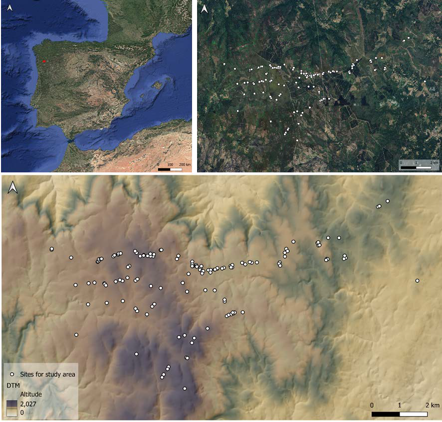

Figure 1. The geographic positioning of the Serra do Laboreiro region within the Iberian Peninsula, and study area with the megalithic monuments (white dots).

```r
knitr::include_graphics(here::here("images", "fig1.png"))
```

Knowledge on the tumular phenomenon at the Portuguese-Galician frontier remains somewhat sparse despite decades of research. Several research initiatives previously led by Spanish and Portuguese institutions, such as the University of Santiago de Compostela (for example, Eguileta Franco, 1999), the Archaeological Unit of the University of Minho, and the Group of Archaeological Studies of Porto (GEAP – Grupo de Estudos Arqueológicos do Porto), in collaboration with regional authorities such as the Xunta de Galicia, undertook extensive survey work across northern Portugal and southern Galicia from the late 1970s to the early 1990s. These efforts have significantly expanded the archaeological record, leading to the identification of numerous new sites and monuments.

Some of the most intensively studied megalithic landscapes in the northwestern Iberian Peninsula are Serra da Aboboreira (Porto, Portugal) (Cruz, 1980, 1992; V. O. Jorge, 1982a, 1983-84, 1992), Trás-os-Montes and the entire region of Entre Douro e Minho (Portugal) (V. O. Jorge, 1987; Silva, 2003; Sanches & Nunes, 2005; Bettencourt & Vilas Boas, 2021), Costa da Morte in Galicia — with the highest density of tumular monuments (e.g. Carrero-Pazos & Rodríguez Casal, 2019) — to which we now add Planalto de Castro Laboreiro (shared between Portugal and Galicia) (López Cuevillas, 1923, 1925a, 1925b; 1973) and the region of Baixa Limia (Ourense) (Eguileta Franco, 1993-94, 1995). These areas contain important concentrations of prehistoric sites dating back to the 5th millennium BC.

In the case of Serra do Laboreiro, successive field surveys have increased the number of identified monuments from 64 to approximately 200 (V. O. Jorge, 1982a: 421; Sousa, 2012; cfr. Canedo et al., 2023), reaching close to 1,000 recorded sites in northern Portugal alone. However, this figure should be treated with caution, as the current national database — Geoportal de Arqueologia do Património Cultural (https://arqueologia.patrimoniocultural.pt/) — likely contains duplicate entries from inconsistent naming and recording practices over the years. Systematic revisions and field verification remain essential, particularly considering the limitations of remote sensing and the application of AI-based detection algorithms (see Canedo et al., 2023, 2024).

Providing a key reference framework for understanding these types of landscapes, to date, Serra da Aboboreira (and the neighboring mountain, Serra do Castelo) remains the one that was thoroughly and extensively excavated, published, and studied during the 1980s and the beginning of the 21st century. Unfortunately, despite this continuous effort, this generated a fragmentary corpus (albeit robust) of knowledge and created an imbalance in available interpretations, scattered over several works, journals, papers and publications over the decades (V. O. Jorge, 1987: 270). And although Aboboreira offers valuable insights, it cannot stand alone as a representative of these landscapes. Indeed, one of the main conclusions from research in Aboboreira is that tumular landscapes should be understood as heterogeneous and polymorphic phenomena (see V. O. Jorge, 1981; Fábregas Valcarce, 1988: 280), whose background rests behind a multitude of practices – most of which unknown or poorly understood – which stretch over an extended chronological period.

As previously mentioned, among the best-known tumular landscapes are the Planalto de Castro Laboreiro and the Baixa Limia region, including Maus de Salas, where 269 barrow-like structures were registered, located at altitudes ranging from 1300 to 700 mASL (**Figure 2**).

Amongst the most debated, surveyed and excavated megalithic group in the Iberian Northwest remains Serra da Aboboreira (Porto, Portugal) (Cruz, 1980, 1992; Jorge, 1982a, 1983-84, 1992), Trás-os-Montes and the entire region of Entre Douro e Minho (Portugal) (Jorge, 1987; Silva, 2003; Sanches & Nunes, 2005; Bettencourt & Vilas Boas, 2021), with Planalto de Castro Laboreiro (shared between Portugal and Galicia) (López Cuevillas, 1923, 1925a, 1925b; 1973), and the region of Baixa Limia (Ourense) (Eguileta Franco, 1993-94, 1995) with important concentration of prehistoric sites as early as the 5<sup>th</sup> millennium BC. In Galicia, Costa da Morte appears to be one of the regions with the highest density of sites, as several researchers have pointed out (e.g. Carrero-Pazos Rodríguez Casal, 2019).

In the case of Serra do Laboreiro, the continuous surveys and field prospections went from the identification of 64 monuments to circa 200 (Jorge, 1982: 421; Sousa, 2012; cfr: Canedo et al. 2023), reaching, today, a little bit over 1,000 registered monuments for the north of Portugal only[^1]. However, although there are, indeed, over 1,000 entries in the current national database – Geoportal de Arqueologia do Património Cultural, I.P. (https://arqueologia.patrimoniocultural.pt/)-, there is a need for an intensive revision, as some sites may have more than one entry under different identifications or names. In this aspect, a remote identification has its limits, something that is being constantly underlined, stating how indispensable conducting thorough fieldwork validation continues to be - and despite the refinement of AI algorithms (see Canedo et al. 2023, 2024).

Only Serra da Aboboreira and its neighbouring mountain, Serra do Castelo, were excavated, published, and studied to their maximum during the 1980s and beginning of the 21<sup>st</sup> century, leaving us a layout for the study of these types of ancient social and territorial contexts. Despite this, the number of monuments is not enough to understand the phenomenon, some defending it even creates a somewhat fragmentary knowledge of it (Jorge, 1987: 270), specifically for the north of Portugal, as we rest mostly on the knowledge of one *necropolis.* That is not to say that the only source of knowledge for this type of contexts rests solely on one example, rather it is the only one where information can be derived out of one single landscape with approximately 40 (excavated) monuments instead of a small group of them. In fact, if there is something that Serra da Aboboreira underlined was that the tumular phenomenon/tumular landscapes is to be regarded as a heterogenous and polymorphic behaviour (see Jorge, 1981; Fábregas Valcarce, 1988: 280), whose background rests behind a multitude of social layouts and variables – most of which unknown or poorly understood – which stretch over a large chronological space.

As previously mentioned, amongst the most well-known tumular landscapes rests Planalto de Castro Laboreiro and its surrounding areas, and the Galician region of Baixa Limia including Maus de Salas, with 269 identified barrow-like structures, some of which identified in the last decades of the 20<sup>th</sup> century, others inedited and recently added to the database. The monuments are located at altitudes ranging from 1300 m.a.s.l. and 700 m.a.s.l. (**Figure 2**).

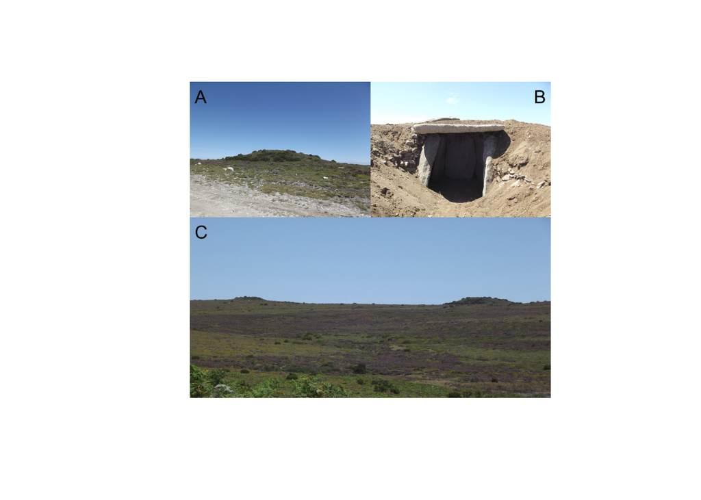

Figure 2. A Mota Grande (A), Mound of Outeiro do Ferro Penagache (B), Outeiro do Ferro Penagache M5 (C). Photographs by Goreti Sousa (in Sousa, 2012, Vol. II, p. 62).

```r
# Load images directly from the images/ folder
img1 <- magick::image_read(file.path(path_images, "OFeM1.JPG"))
img2 <- magick::image_read(file.path(path_images, "OFeM3_Dolmen.JPG"))
img3 <- magick::image_read(file.path(path_images, "Landscape.JPG"))

# Resize and compose
target_width <- 800
img1 <- magick::image_resize(img1, paste0(target_width / 2, "x"))
img2 <- magick::image_resize(img2, paste0(target_width / 2, "x"))
img3 <- magick::image_resize(img3, paste0(target_width, "x"))

# Annotate labels
img1 <- magick::image_annotate(img1, "A", gravity = "northwest", location = "+10+10", size = 40, color = "black")
img2 <- magick::image_annotate(img2, "B", gravity = "northeast", location = "+10+10", size = 40, color = "black")
img3 <- magick::image_annotate(img3, "C", gravity = "northwest", location = "+10+10", size = 40, color = "black")

top_row    <- magick::image_append(c(img1, img2), stack = FALSE)
composition <- magick::image_append(c(top_row, img3), stack = TRUE)

# Show the image using plot() to ensure it renders in Quarto
plot(composition)
```

In Laboreiro, most of the monuments remain unexcavated. Their internal structures may include megalithic chambers like dolmens or cists, each referring to particular chronological phases. This variation in the architectural configuration (open dolmens, closed dolmens, dolmens with corridor, megalithic cists) (see Criado Boado & Fábregas Valcarce, 1989: 688, 692) seems to suggest different timelines not too distant chronologically, as some already suggested (López Cuevillas, 1973; Rodríguez Casal, 1979; Cruz, 1992: 69-72).

The long-term use of these monuments, from their construction to abandonment and later reuse, makes it challenging to define discrete phases of activity, mainly because of the limited availability of datable material. As a result, research often shifts the focus from individual monuments to their broader landscape context, emphasizing the relationship between human groups and their landscapes.

Thus, considering that this phenomenon marks an important development in the deliberate demarcation of space through funerary architecture (Renfrew, 1973, 1976; Díez Castillo, 1996: 32; Murrieta-Flores, 2012), and since many aspects of their builders’ intentions and background will remain inaccessible, there are common characteristics in terms of their territorial display that suggest the existence of shared criteria related to territorial display. Something also extensively studied in other areas of the Iberian Peninsula, such as the Gor necropolis in Granada (Esquivel et al., 2021; Cabrero González et al., 2025).

These criteria appear to involve both natural elements and geomorphological features (Villoch Vázquez, 1995; Criado Boado, Villoch Vázquez, 2000; García Sanguán, 2008; Blas Cortina, 2010), an aspect of particular relevance given the context in which this phenomenon emerged: communities partly mobile, but engaged in early forms of production, and in combination with pastoralism, hunting, and gathering (Díez Castillo, 1996; Fábregas Valcarce & Vilaseco Vásquez, 2006: 2).

Our ability to quantitatively analyze and describe these patterns has been significantly improved by recent advances in digital methodologies, such as Geographical Information Systems, Artificial Intelligence and Spatial Statistics, as well as a renewed interest in their application in current archaeological science (Bevan, 2015; Cortell-Nicolau & Pardo-Gordó, 2023).

The importance of spatial relationships has already been recognized in earlier studies, even if fieldwork traditionally focused on architectural features such as chambers and corridors. Key factors frequently associated with the monument’s placement included the proximity to rocky outcrops (for example, L’Helgouac’h, 1965; Bueno Ramírez, 1988; Criado Boado & Grajal, 1981; Criado Boado, 1984: 9-10; Linares Catela, 2020: 91), natural passageways (Criado Boado, Vaquero Lastres, 1991; García Sanguán et al., 2009; Cabras, 2018; Murrieta-Flores, 2012, 2014; Llobera, 2000; Carrero Pazos, 2017: 137; Rodríguez Rellán & Fábregas Valcarce, 2019), proximity to water bodies (Tilley, 1994: 67, 123; O’Sullivan, 2011: 65), and arable lands (Criado Boado & Grajal, 1981: 23; Bello Diéguez et al., 1982), to which we can add the (inter)visibility and topographic prominence (Criado Boado, 1984: 14, 1988: 669; Cabrero González et al., 2020).

Based on previous research, here we analyze variables such as altitude, slope, cumulative viewshed, distance to rocky outcrops, main landscape features, hydrographic basins, and natural pathways. Given the strong relationship their construction seems to have with the territory throughout the centuries, spatial statistical analyses are appropriate frameworks for addressing the current lack of data derived from direct excavation.

## 2 Methods and analyses

### 2.1 Spatial Statistics

The potential of statistical methods and GIS in archaeology has been extensively explored and documented. This is particularly noteworthy given the advancements in digital tools and technological improvements that have characterized the last two decades (see e.g. Mehrer & Wescott, 2006; Carlson, 2017; Verhagen, 2018; Gillings, Hacıgüzeseller & Lock, 2020). Archaeologists have eagerly embraced new techniques to assist in establishing methods for interpreting records and organizing data. Similarly, the application of practical and digital methods has surged, in line with new theoretical hypotheses (Hu, 2011; Gillings, 2012).

The ones highlighted in this text stem from the tumular phenomenon debate in respect to those main territorial attributes, i.e., a study on a regional scale of a set of monuments in a mountain environment. As most of the monuments have no information from excavations, the study focuses essentially on direct and observable territorial attributes of the relation between the megalith’s setting and their surroundings.

Studies on landscape archaeology based on Spatial Statistics are not new in the Iberian Peninsula (Parcero Oubiña & Fábrega Álvarez, 2006; Yubero-Gómez et al., 2015; Berrocal-Rangel et al., 2018; Rubio Campillo et al., 2022; Carrero-Pazos et al., 2019; Díaz Rodríguez & Fábregas Valcarce, 2022), and the potential they pose proves to be of great utility especially when confronted with case studies that lack formal and direct evidences. However, their application on tumular landscapes is still somewhat incipient, with greater incidence in the Iberian Northwest (Llobera, 2015; Carrero-Pazos et al., 2020; Higginbottom et al., 2022; Berganzo-Besga et al., 2021; Rodríguez del Cueto & Carrero-Pazos, 2021a, 2021b) and the South (Murrieta-Flores, 2012, 2014). Despite the variety of methods used in these analyses and the observation of point distributions and spatial interactions between them, several courses of action may be considered based on the specificities of the study area and the questions to be answered.

We know that behind these monuments rests a multitude of different behaviours extended over large periods of time. From previous readings, be them before or after the introduction of computational approaches, we can also positively assume some *de facto* aspects: (i) the monuments may occur in the landscape in clusters or isolated, and (ii) may represent distinct chronologies, therefore, we can also positively assume that (iii) the existence of previous monuments is a factor of influence for the construction of new structures in later periods (Carrero-Pazos et al., 2019). Consider, for example, Outeiro de Gregos in Serra da Aboboreira (Portugal), a cluster of five monuments ranging from the beginning of 4th millennium BCE, to the 2nd millennium BCE (V. O. Jorge, 1981), or even the Necropolis of Lafões in Viseu (Portugal), a cluster of circa 114 monuments also ranging from the beginning of the 4th millennium until the XII-VII century BCE (Carvalho & Carvalho, 2018: 41).

### 2.2 Archaeological data. Ground truthing through LiDAR data

The study area is in the current frontier territories over Ourense province (Galicia, Spain) and the Melgaço municipality (district of Viana do Castelo, north of Portugal). The archaeological data used in this work is the result of several fieldwork campaigns that some of the authors did in the past (Vilas Estévez, 2015) and current revisions from AI approaches (Canedo et al., 2023, 2024).

For this work, we decided to carry out a ground truthing initial phase based on LiDAR data to check the reliability of the spatial coordinates of the sites. As such, the generation of the DEM and its pretreatment is the first step for the entire analytical process and through which all the spatial covariates can be modelled from (see Berganzo-Besga et al., 2022). For this, we used the available LiDAR data for Spain (Geographical National Institute, IGN - https://pnoa.ign.es/pnoa-lidar/presentacion), and for Portugal the LiDAR data was obtained from the Comunidade Intermunicipal do Alto Minho (CIM Alto Minho), under the collaboration by one of the authors of this paper (JF). The provided LiDAR data has a point cloud density of 2 points per square meter for the Portuguese part. For the Spanish (Galician) part, the LiDAR data has a point cloud density of 0.5-2 points per square meter (see https://pnoa.ign.es/web/portal/pnoa-lidar/especificaciones-tecnicas).

The DEM was created using *LAStools*, keeping only the bare ground points with the plug-in *lasground*. The resulting point clouds were merged in *SAGA-GIS 8.5.0*, and the resulting raster was interpolated through Angular Distance Weighting (ADW) (Shepard, 1968). We decided to use ADW instead of the more common Inverse Distance Weighting (IDW), in this case, for the sake of computer efficiency. The interpolation resulted in a DEM with a 1m resolution.

This cleaning process permits a better observation of the terrain, with no other categories but the terrain itself, which makes easy the visual identification of the megalithic mounds (Opitz & Cowley, 2013). The ground truthing step required for the terrain observation and confirmation of the tumular occurrences involved the generation of a hillshade from the DEM and other raster visualization techniques (see Berganzo-Besga et al., 2021; Berganzo-Besga et al., 2022). In this way, we used the Relief Visualization Toolbox (RVT) (Zakšek et al., 2011; Kokalj & Somrak, 2019) to create other convenient visualization outputs, such as the sky-view factor or a local relief model (Kokalj & Hesse, 2017). We also used the *Resampling filter* from SAGA GIS, creating additional images with distinct categories in colour and shading that, when compared against the generated hillshade, helped us with the site’s identification. The ground truthing process took into consideration an initial database of 269 points corresponding to monuments identified in field surveys, either from previous prospections or more recent ones (Eguileta Franco, 1999; Sousa, 2012; Vilas Estévez, 2015). The database we are providing comprises the name of the monument and the UTM coordinates – easting and northing.

To carry out the ground truthing we used ArcGIS where a point shapefile was created and used against the generated raster images. The points typically contrast with the shapes seen in the images aiming to confirm the correct georeferentiation of the monuments during the fieldwork, confirming both a correct identification and a remote LiDAR successful detection. This second step on the process generated a total of 178 points, meaning that 91 monuments were excluded from the ground truthing process according to the chosen parameters: 46 duplicated points from previous databases with monuments registered under two distinct identifications, and 45 points whose remote identification as mounds is dubious and the in-site recognition is not known.

### 2.3 GIS modelling. Covariable set up

The main landscape features previously mentioned are those that have been addressed by different authors as possible predictive variables of the megalithic mounds in Galicia and other regions (see the introduction chapter). Thus, in the case of this research, a data-driven model (Verhagen, 2018) reflects more accurately the factors we have at hand: altitude, slope, distance to main geomorphological features and water sources, etc.

Therefore, several digital models were created from the DEM, according to the variables previously discussed: Slope, Cumulative Horizon, Cumulative Viewshed, Distance to Ridges, Distance to Water Edges, Distance to Rocky Outcrops, Least Cost Paths and Topographic Prominence. Distinct programs were used to create and define the raster covariates: ArcGIS 10.4, SAGA-GIS 8.5.0, Grass GIS 7.8, QGIS 3.28 Firenze, and R Studio v. 4.3.0.

- Slope
- *ArcMap*, using the Surface in Spatial Analyst Tool
- Cumulative horizon
- *QGIS 3.28 Firenze* through the Visibility Analysis plugin (Čučković, 2016)

The intent was to model the horizon of the landscape, meaning the outer edges of a viewshed. 1,000 viewpoints where regularly generated and evenly distributed beforehand alongside the entire study area to cover the total landscape under analysis.

Cumulative viewshed

- QGIS 3.28 Firenze. Similarly to the previous variable, we used the visibility index analysis from the Viewshed Analysis plugin (Čučković, 2016)

1,000 viewpoints were generated across the entirety of the study area, a radius of analysis of 3,000 meters and an observer height of 1.60 meters. The Visibility Index considers the proportion of a given area that is visible from a given observer location, attributing different values to raster cells considering the higher or lower degree of visibility, useful when the objective is the identification of areas in the landscape with the best visibility index.

| Distance to ridges | *GRASS GIS* with *r.geomorphon*. It allows to calculate, classify and map the terrain elements from a DEM (Jasiewicz & Stepinski, 2013). |
| --- | --- |

The objective was to identify the main terrestrial landforms in the study area through the generation of geomorphometric maps and extract the ones that appeared to be of significance to our analysis. To identify the main terrestrial landforms, several maps were generated according to different scales and radius. Five scales were tested:

- Outer radius = 20, inner radius = 5
- Outer radius = 15, inner radius = 5
- Outer radius = 35, inner radius = 0
- Outer radius = 32, inner radius = 0
- Outer radius = 64, inner radius = 5

It is important to emphasize that the primary goal in defining the main landforms in the study area is closely related to identifying distinct shapes in the geomorphology, meaning, the main scenery cut against the horizon and the sky – things that can be easily recognized while traversing the landscape. Based on this, the critical visual analysis of the results determined that a radius of 64 units captured the key points in the landscape, enabling a faster identification of the main landforms. Therefore, among the 10 categories defined in *r.geomorphon*, ridges, shoulders and spurs (categories 2, 3, and 4 respectively) showed to be the most promising. The raster calculator (*r.mapcalc*) allowed for the extraction of these specific landforms, so the final result was a raster file with information that regarded solely to landform categories 2, 3 and 4. Lastly, and because we want to ponder on the distance between specific points in the landscape, we applied *r.grow.distance* to determine the distance between the features in the landscape.

- Distance to watershed edges
- *GRASS GIS* with *r.watershed* (original version by Ehlschlaeger, 1989).

To calculate the watershed edges we used hydrological modelling, which calculates flows and basins in a DEM by generating a series of maps according to different parameters: flow accumulation, drainage direction, location of streams, watershed basins. Our variable, however, considers only watershed basins. As it requires a minimum size of the exterior watershed to be set, we tested two sizes: a threshold of 50000 units and 25000 units. A visual analysis concluded that a threshold of 25000 showed more detailed results, outlining specific watershed basins. *R.grow.distance* was then used to calculate the distance from the watershed edges to the rest of the study area.

- Distance to rocky outcrops
- ArcMap, with the creation of a shapefile and drawing polygons against the satellite images for Spain (Plan Nacional de Ortofotografía Aérea (PNOA) https://pnoa.ign.es/) - and Portugal (Direção Geral do Território - DGT, Ortofotos 25cm – Portugal Continental - 2018)

This variable required a bit more elaboration, as currently there is not any vector cartography that we can use. The raster geological maps available from the Spanish and Portuguese Geographic National Institutes were too general to be used. Thus, the creation of the variable implied a vectorization of all the rocky outcrops visible in aerial imaging though a Web Map Service. Again, *r.grow.distance* was applied to determine the distance between the rocky outcrops and the rest of the terrain.

[output not shown]

It follows the assumption that the topography of the terrain where the monuments were built is of a major influence. One of the algorithms widely used for this purpose is usually the *Topographic Position Index* (TPI) from *SAGA GIS* (e.g. Bustelo Abuín et al. 2017), which takes into consideration the relative topographic prominence of a feature in the landscape at different scales and integrates it into a single grid. As the output is highly dependable on scales (Weiss, 2001), the characteristic of the landscape needs to be considered not only counting the landscape under analysis, but also the objectives under scrutiny. So, we must model this variable considering this landscape’s characteristics, which in this case is mainly constituted by open slopes and plains.

As different landscapes have different geomorphological features, some digital models should be generated in accordance with said features. This is particularly true for this variable that considers topographic prominence, as it is scale dependent. Thus, we used the Multiresolution Index of Valley Bottom Flatness (MRVBF) and the complementary Multiresolution Index of the Ridge Top Flatness (MRRTF) to define valley bottoms as areas which were flat and low relative to their surroundings (Gallant & Dowling, 2003: 9). As both open slopes and plains are characterized by flat terrain and low to gradual slope angles, we determined a value of 18 for the *Initial Threshold for Slope*, a *Shape Parameter of Slope* of 2, and a *Shape Parameter for Elevation Percentile* of 1, leaving the remaining parameters with their default setting. Then, the determination of the surface and flat areas was determined by the initial threshold: the higher the value, the flatter the surface.

We include some of the modelled covariates in the **figure 3**.

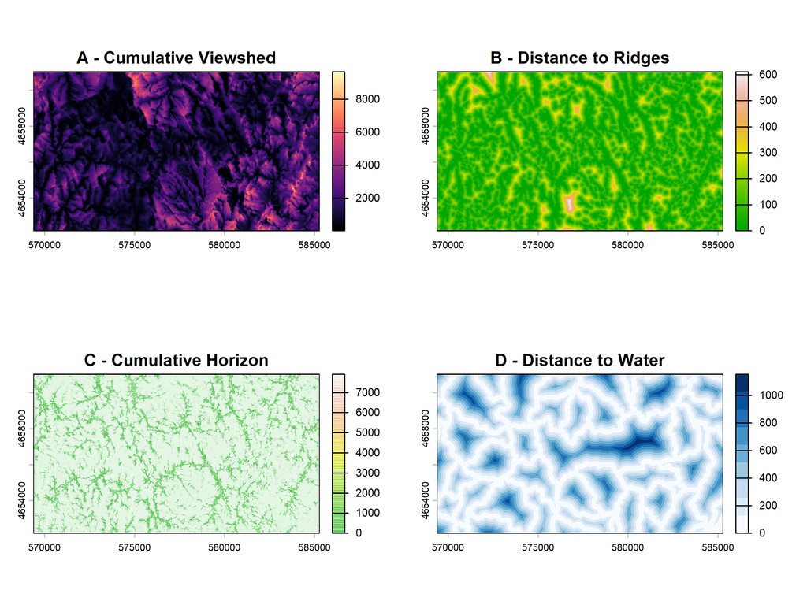

Figure 3. Some of the variables modelled in a GIS environment for this work.

```r
knitr::include_graphics(here::here("images", "fig3.png"))
```

## 3 Descriptive approaches to the distribution of sites

The study of barrow landscapes considers looking into patterns that could refer to similarities in the dimensions of the mound and/or chamber, existence/absence of corridor, type(s) of material culture or presence/absence of remains, or even megalithic art. These similarities could be then compared between 1) the geomorphological and topographical features, and 2) the characteristics of the structure’s implantation in the terrain – both at a macro and micro scale (Lima e Silva, 2025). But of course, this can only be done when we have access to data referring the structures themselves, and their respective material cultural, stratigraphy, and not just their spatial context.

If a pattern exists, we could be dealing with a particular type of human group or observing a certain behaviour that could, in turn, be chronologically narrowed down. Cases where this can be done are not so common (see, for example, Esquivel et al., 2021, Cabrero González et al., 2025, stressing the tumular landscape alongside the Gor River, Granada), as one would need a landscape fully excavated without the general absence in artefactual evidence, as well as chronometric data.

Another important constriction is that we lack knowledge on some factors of social order in prehistoric times (especially when we confront the data for 5th and/or 4th millennium with the data for the 3rd and end of 2nd millennium), such as demographic growth, territorial disposition, and organization, etc. So, it becomes even more difficult when we try to conduct a study based solely on a point distribution.

It is important to clearly define what we can observe from it, considering these unknowns, which, in the context of the present text, must be framed strictly within a spatial and primarily digital and bibliographical approach. As an example on how some obstacles can be accounted for, for instance, consider Tobler’s First Law of Geography which states that nearby elements tend to have stronger relationships than those farther apart. In terms of this paper’s main objective –long-term human-landscape behaviour through the analysis of a non-random, clustered distribution of points– this means we can analyse it from two perspectives (and similarly to how G. Čučković forwarded it (Čučković, 2025: 234, table 15.1.)):

1. On a large scale, that is, looking at how natural landscape features influence human movement within a particular environment.
2. On a small scale, that is, observing how individual monuments, the points, interact with each other.

Essentially, this allows us to move from broad spatial relationships to more localized ones. These reflect two levels of influence considering we are essentially dealing with human behaviour strictly from a spatial point of view: the landscape, while perceived and shaped by humans, is also subjecting humans to its geomorphological constraints, so there will always be a limit to how we can use a territory. Consequently, there is a limit on how we can quantify these several strategies implemented by people over long diachronies.

Several approaches can be used to quantify these relations, such as Moran’s I Method, or the application of non-parametric estimations (*rho-hat* function, see Kempf & Günther, 2022). In this case we will opt for the widely used comparative approach between the site locations and a sample of the background terrain, based on multiple Monte Carlo Simulations, with the implementation of a Mann-Whitney test to formally test whether the site locations were likely a random sample of locations drawn from the study area or not (see Connolly, Lake 2006; Bevan et al. 2013; Bevan, 2020). This can be done in *R Statistics* using the *rbias* package (Kempf & Günther, 2022), with implementations from K. Bocinsky (2017), by calculating and graphing a Monte Carlo sub-sampled kernel density estimates for random locations over which we can include the sites specific trends (**Figure 4**).

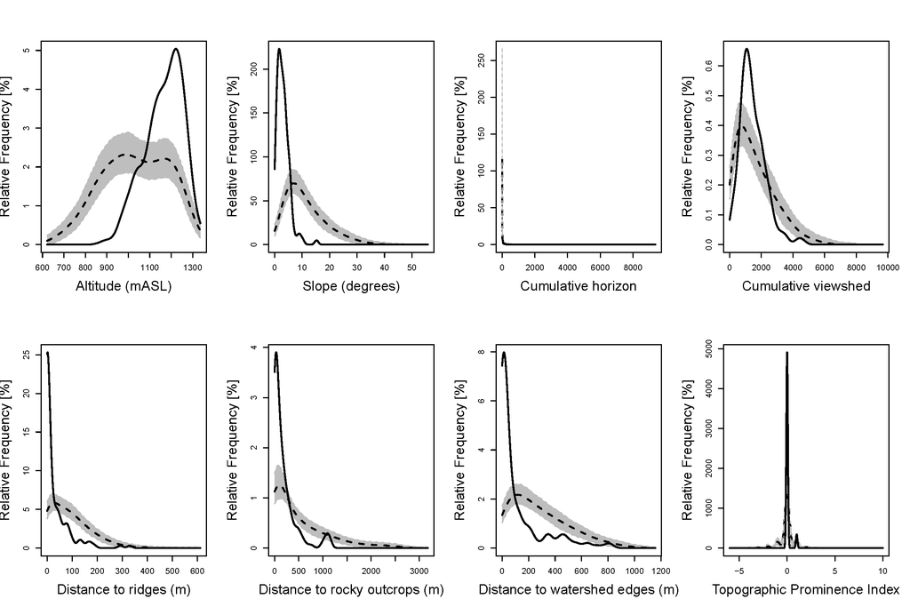

Figure 4. Site trends versus the terrain background. The solid line in the graphs represents the sites; The dashed line corresponds to the median of the random points; The shaded area is the confidence intervals (5%, 95%) based upon 999 Monte Carlo Simulations placed over the study area (based on Kempf & Günther, 2022; Bocinsky, 2017).

```r
knitr::include_graphics(here::here("images", "fig4.png"))
```

**Analytical code for simulations (Click to expand)**

```r
# Create a function to iterate the simulation process
perform_simulation <- function(covariate, covariate_name) {
  simulation_result <- sites_vs_background(covariate = covariate,
                                           sites = sites,
                                           nsim = 999,
                                           covariate_name = covariate_name)
  return(simulation_result)
}

# Define a list of covariates and their corresponding names
covariates <- list(
  dem = "Altitude mASL",
  slope = "Slope %",
  cum_horizon = "Cumulative Horizon",
  cum_viewshed = "Cumulative Viewshed",
  dist_to_ridges = "Distance to Ridges",
  dist_to_rocks = "Distance to Rocks",
  dist_to_watedges = "Distance to Water Edges",
  tpi = "Topographic Position Index (TPI)"
)

# Apply the simulation function to each covariate
simulation_results <- lapply(names(covariates),
                             function(covariate) {
  perform_simulation(get(covariate),
                     covariates[[covariate]])
})

# Plot
par(mfrow = c(3, 3), mar = c(5, 5, 2, 3))
for (i in seq_along(simulation_results)) {
  simulation_result <- simulation_results[[i]]
  if (!is.null(simulation_result)) {
    # Create the plot using simulation_results_plot()
    simulation_results_plot(simulation_result, show_title = FALSE)
  }
}

# Part 2 Compute two-sample Wilcoxon tests (Mann-Whitney U tests)
# Generate random background samples for each covariate
random_samples <- lapply(simulation_results, function(simulation_result) {
  if (is.null(simulation_result)) return(NULL)
  ras_samples <- simulation_result$ras_samples
  lapply(ras_samples, function(ras_sample) {
    sample(ras_sample,
           length(simulation_result$sites_densities$Covariate),
           replace = TRUE)
  })
})

# Create a progress bar
pb <- progress::progress_bar$new(total = length(simulation_results),
                       format = "[:bar] :percent :eta")

# Perform Wilcoxon test for each covariate
wilcoxon_results <- lapply(seq_along(simulation_results), function(i) {
  simulation_result <- simulation_results[[i]]
  background_samples <- random_samples[[i]]

  if (is.null(simulation_result) || is.null(background_samples)) {
    return(NULL)
  }

  # Update progress bar
  pb$tick()

  # Perform Wilcoxon test for each background sample
  wilcoxon_test_results <- lapply(background_samples, function(background_sample) {
    if (length(background_sample) < 2 ||
        length(simulation_result$sites_densities$Covariate) < 2) {
      return(data.frame(statistic = NA, p.value = NA))
    }
    # Set directionality: distance variables use "less", others use "greater"
    alt_dir <- ifelse(names(covariates)[i] %in% c("dist_to_ridges", "dist_to_rocks", "dist_to_watedges"),
                      "less", "greater")

    result <- wilcox.test(simulation_result$sites_densities$Covariate,
                          background_sample,
                          alternative = alt_dir,
                          exact = FALSE)
    broom::tidy(result) %>% select(statistic, p.value)
  })

  # Combine the results
  wilcoxon_test_results <- bind_rows(wilcoxon_test_results)

  # Get the median test statistic and 95% confidence interval
  wilcoxon_summary <- foreach::foreach(prob = c(0.025, 0.5, 0.975), .combine = rbind) %do% {
    wilcoxon_test_results %>%
      dplyr::summarise_all(quantile, probs = prob)
  } %>%
    t() %>%
    magrittr::set_colnames(c("Lower CI", "Median", "Upper CI"))

  # Create a data frame for the covariate and add covariate_name
  covariate_summary <- data.frame(covariate = names(covariates)[i])
  wilcoxon_summary <- cbind(covariate_summary, wilcoxon_summary)

  return(wilcoxon_summary)
})

# Combine the results for all covariates
wilcoxon_results <- do.call(rbind, wilcoxon_results)

wilcoxon_results
```

The Mann-Whitney test, commonly referred to as Wilcoxon rank-sum test, is a non-parametric test used to observe and compare two independent groups, assessing if there is or not a statistically significant difference between the distribution of a variable in said independent groups. In this case, this translates to whether there is a statistically significant difference between the points distribution – the tumular structures – and the geomorphological constraints that were modelled, tested against a set of randomly generated points alongside the study area via 999 Monte Carlo simulations (Conolly & Lake, 2006: 127; Kvamme, 2020: 218; Günther, et al., 2022; Bocinsky, 2017).

The usefulness in using this method relies on the fact that it is not dependent on previous assumptions about the underlying data distribution. Our chosen confidence level was defined at 95%, with a *p*-value below 0.05. A value under that threshold represents a statistically significant difference between the real sample and random sample. We also include the U Statistic, a confidence interval which allows us to quantify the difference in ranks between the archaeological sample and a random one, that mean in our case, the ranks of the covariate values at site locations versus those at random background locations. The results are provided in the supplementary material (under data/derived folder).

## 4 Laboreiro’s spatial structure based on the monuments

We’ve established that these points —whether in clusters or isolated— might be representing distinct (social) landscapes at different times. But, by analysing them together with these digital methods we end up merging different landscapes into one, and we overlook the true diversity and dynamism of this territory. Our main challenge, thus, becomes: how do we account for the fact that these methods and tests inherently treat a landscape that has evolved over time as if it were static and unchanging?

So, it comes with no surprise that, in statistical terms, at least one variable –the altitude– stands out as the most important one. This could be interpreted as meaning that altitude has prevailed as a variable of transversal importance for many centuries in association with this phenomenon. Evidence of other human choices may lie in the other, slightly less statistically relevant variables, perhaps precisely as a response to the already established relationship with altitude and mountain environments, and to the many adaptations that this relationship has undergone throughout the centuries.

However, it is important to separate them: what the statistical results say in opposition to what it means in terms of human interpretation of the terrain. And here lies the basis in understanding Laboreiro’s true spatial structure. So, although the variable representing altitude proved to be the most important, there are indeed points of significance associated with variables such as cumulative horizon, distance to ridges, rock outcrops, watershed edges, and topographic prominence. These appear to reflect the main spatial tendencies and/or geomorphological constraints with which these groups had to interact and adapt.

The visibility will also always remain an important and unavoidable aspect when crossing any territory. The results of those two variables (Cumulative Viewshed and Horizon) might not have been as promising as expected due to this high level of structural heterogeneity that could not be modelled in this work (lack of formal data). So, if the altitude is being deemed as the main feature for this distribution, it becomes understandable why the horizon and the ridges are diverting some attention as well. Lines in the horizon are always visible elements, and they can articulate how a territory can be perceived, manipulated and managed (and even how to shape its cultural significance and its social boundaries). The same goes for drainage ridges or even the distance to sources of raw materials.

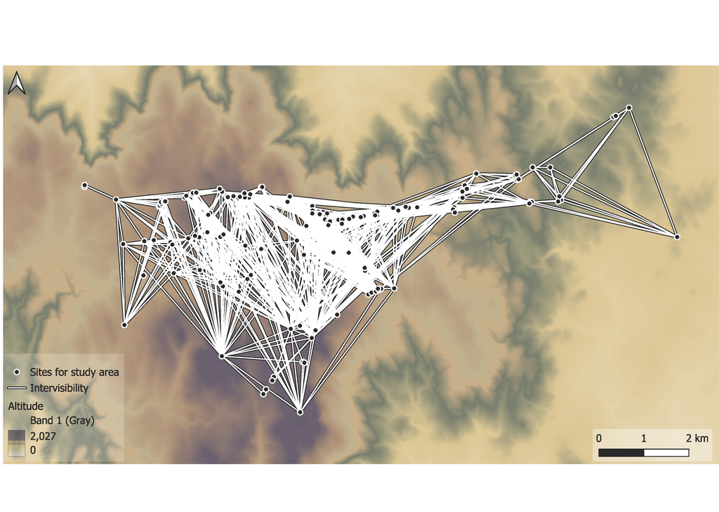

Figure 5. Visual networks over the mounds in Laboreiro region, created with the visibility analysis plugin from QGIS (Čučković, 2016).

```r
knitr::include_graphics(here::here("images", "fig5.png"))
```

This was an exercise to directly observe if there is a network structure based on visibility form the implantation of the monuments. We noticed the existence of areas which almost devoid of visibility relations, or, at least, with very specific and/or more local ones. Based on this, we proceeded to scrutinize even more to understand the previously stated hypothesis: there are monuments that ended up dictating how this landscape could be arranged considering the main geomorphological features and how people might have committed with them.

What this could entail is that the megalithic sites are not creating a visual network of the landscape, but demarcating one that already existed, only now materialized with these constructions as social markers of the living territories. In the end, these variables end up determining the main perceived shapes of a given territory –from lines on the horizon to true physical landmarks against them.

To formally address this idea, we can use a logistic regression approach combined with the creation of three spatial point process models which allow us to deeply understand the characteristics of the spatial distribution of the mounds (see Carrero-Pazos et al., 2019 for the original approach we are using here). The logistic regression map was built using selected covariates in this research (elevation, cumulative horizon, slope and a raster variable resulting from the sum of those main geomorphological features: rock outcrops, ridges and watershed edges), allowing us to understand to what extent these environmental variables are influencing the placement of the mounds (**Figure 6b**, **Figure 6c**). All those analyses were built in *R Statistics* using the *Spatstat* package (Baddeley et al., 2016).

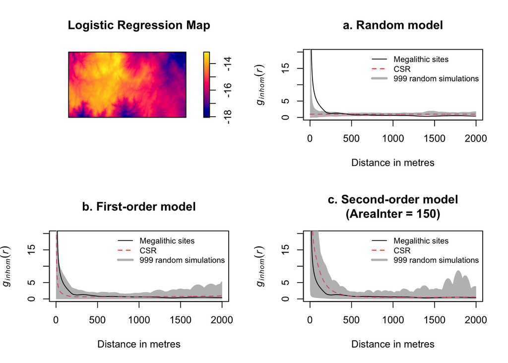

Figure 6. Spatial statistical models to understand the relationship between the mounds and their surrounding environment. a) purely random model; b) 999 random simulations based on the covariates -first-order surface-; c) 999 random simulations based on the first-order surface and an area interaction model for each point.

```r
knitr::include_graphics(here::here("images", "fig6.png"))
```

## 5 Results

Of all the variables that were modelled – Altitude, Slope, Cumulative Horizon, Cumulative viewshed, Distance to Ridges, Distance to Watershed Edges, Distance to Rock Outcrops, Topographic Prominence – the covariates with significant median p-values are the Altitude, Slope, Cumulative Horizon, Distance to Ridges, Distance to Rock Outcrops, Distance to Water Edges and Topographic Prominence, indicating that these environmental variables are likely important in determining the site spatial pattern, with a preference for high, prominent, flat ridge-tops. In contrast, the Cumulative Viewshed (p = 0.81) yielded non-significant results, suggesting that the total visible areas are not primary drivers for site distribution (Table 1).

[output not shown]

A cross reading from the results indicate that sites are likely located at higher altitudes than expected by chance, and on specific slopes compared to the surrounding landscape. This might relate with other factors, such as the proximity to water sources or the visibility. The latter could be the case, as the analysis of the cumulative horizon and the cumulative viewshed indicates that the sites might have been intentionally placed in areas with specific viewsheds or horizon properties, playing the topographic prominence also an important role. The high visibility may have been a key factor in the placing of the megalithic sites, likely for communication, controlling of the surrounding landscape or a symbolic dominance, perhaps even a preexisting one. Even though it’s statistically insignificant, prominent viewsheds remain a relevant factor, almost intrinsic to this geomorphological reality.

Although a single variable may capture the overall influence of geomorphological constraints on these communities’ responses to the landscape, our analyses suggest that local features may exert a stronger influence on site selection.

## 6 Discussion

Even though the results identify statistically significant relationships between site location and certain covariables, they rely on a level of inconsistency precisely due to the fact that these landscapes are fundamentally diachronic. We could even forward the debated “satellitization” processes, meaning newer monuments being built next to old ones – acting as “satellites” (Carvalho & Carvalho, 2018: 46; Carrero-Pazos et al., 2019).

As discussed at the beginning, it can be highly ambitious not only to assess the temporal dynamics of these monuments individually, but also to study a landscape that was constructed and transformed over centuries. Accordingly, the main criticisms of the use of digital tools rest on the argument that they cannot adequately capture the diachronic aspects of such landscapes.

Serra da Aboboreira (Porto, Portugal) provides a clear illustration of this variability. The Outeiro de Gregos cluster represents a long-term accumulation of monuments from the beginning of the 4th millennium BC to Final Bronze Age and with distinct architectural forms representing each chronology. In contrast, monuments such as Mina do Simão (V. O. Jorge, 1984), challenge the classical patterns, having been built isolated, at the base of a slope, lacking both topographic prominence and with no extended visibility. With these contrasting cases we can discuss how these tendencies in the monument placement are not prescriptive and that the human agency is not determined by environmental constraints but instead operates within them.

To further reinforce this complexity, we can look more deeply to the stratigraphic evidence. Several monuments exhibit thin layers rich in charcoal or ash, suggesting those spaces were cleaned through fire prior to construction (Outeiro de Gregos 1, Chã de Santinhos 1, or Mamoa da Igrejinha, all from Serra da Aboboreira. V. O. Jorge, 1980c: 16; 1989: 387; Cleto & Faro, 1988: 50, respectively).

Recent micromorphological analysis to undisturbed sections of Anta 1 do Vale da Laje (Tomar, Portugal) indicate sequences of activity that include the clearance of vegetation through fire, construction-related disturbances with scratching of large surfaces, forest regrowth and phases of abandonment, and later reuse testified by yet another clearance of vegetation (Adewumi, 2018-2019: 14, 39-40). This entails that each monument encapsulates a succession of distinct events and activities and are not to be viewed as single temporal entities.

Indeed, this level of continuous interactions post or even pre monument construction is confirmed in several other territories and it is widely accepted that the monuments represent precisely the places of habitation of these communities (cf. Bradley, 1998). The Damsbo Mark site (Denmark) is of particular interest being a (demolished) passage chamber built next to a previous occupation place where traces of a longhouse were excavated (Andersen, 2026: 161).

In the Iberian Peninsula, sites such as the previously mentioned tumular landscape of the River Gor (Granada) (Esquivel et al., 2021; Cabrero González et al., 2025), Campo de Hockey (Bay of Cádiz) (Vijande-Vila et al., 2022), Dolmen do Dombate (Bello Diéguez, 1992/93; Bello Diéguez et al., 2013) and Forno de Mouros 4 and 5 (both in Galicia) (Mañana-Borrazás, 2012, slide 44, 54) are also representative of this additive and cumulative character of the tumular phenomenon, where the same spaces hold distinct tumular structures, normally with the more recent one eclipsing preexisting structures.

Beyond the Iberian Peninsula, different regions in France (Brittany, Channel Islands, Paris Basin) are also representative of the long-term construction of territories taking tumular monuments, with evidence through absolute dating reaching as far back as the 6th millennium BC (Paulsson, 2017: 34, 95). Here we can also see a high level of structural heterogeneity, with the Passy monuments (La Sablonnière and Richebourg), or other more diverse complexes like the Balloy, Le Réaudins necropolis, with 18 monuments and 45 burials, an enclosure and habitational structures (idem: 26-27).

This dynamism is, of course, not exclusive to the tumular phenomenon; however, this phenomenon reflects the long-term interactions and relationships that human groups can create and sustain over centuries. It is in these aspects that a certain level of variability becomes apparent—not in the data or the methods, but in the inherent heterogeneity of these landscapes. Hence, there is a need to scrutinize our sample more closely, despite the initial results indicated by the Wilcoxon test.

## 7 Conclusion

This research has contributed to the debate of the complex interplay between the role that some environmental variables could have in the explanation of the spatial patterns of the mounds and megaliths of Serra do Laboreiro. Our research has shown that some variables, such as the altitude, slope, cumulative horizon and topographic prominence might have influenced the spatial location of the monuments. The prominence of those factors might be supporting the hypothesis that the mounds and megaliths in this region could have been strategically located to optimize their viewsheds, potentially related to communication, territorial control or symbolic purposes. This adds new data for current debates in the megalithic phenomenon of Northwestern Iberia and other European regions (see e.g. Higginbottom et al., 2025).

Also, the spatial patterns modelled in this work reflect a diachronic use of the landscape, where different occupation strategies might be employed over time. Despite these promising insights gained through computational and quantitative modelling, our study also acknowledges the inherent limitations of those tools in capturing the full complexity of a landscape in continuous transformation. The archaeological evidence, including micromorphological analyses, could reveal in this area that the site selection would involve some works such as land preparation or controlled burning, further emphasizing the role of human agency on shaping the landscapes (see e.g. Rodríguez del Cueto et al., 2023).

Ultimately, our research helps reinforcing the idea that while environmental factors could significantly have influenced the site placement, the general spatial distribution cannot be reduced to a single deterministic model. Instead, research like this one reflects a dynamic interaction between human cultural practices, environmental affordances and long-term social landscape transformations. Future works should try to integrate additional qualitative data and diachronic analyses to refine our understanding on settlement strategies, megalithic and mound placing, and the process of formation of those complex monumental landscapes.

## Reproducibility statement

The research contained in this paper was carried out comprising current standards for open access and reproducible frameworks in archaeology, by using a scripting statistical language such as R Statistics and sharing the research data and results in collaborative ways. The data and scripts are available under a Zenodo repository (https://zenodo.org/records/15480087), and GitHub for collaborative work (https://github.com/MCarreroPazos/MegalithsLaboreiro). R scripts are released under MIT license and archaeological data and results are shared under CC BY-NC 4.0.

Large Language Models (LLMs) have been used for coding assistance, polishing, and ensuring reproducibility. The authors are responsible for the content and accuracy of the analysis and findings reported in this manuscript.

R Statistics package citation is done using the [grateful package](https://pakillo.github.io/grateful/index.html), with a summary `.bib` file included in the root directory of the project (see GitHub page).

```
Install `grateful` to auto-generate package citations.
```

## Acknowledgments

Denise Lima e Silva is funded by FCT Foundation for Science and Technology (FCT scholarship nº. 2020.04713.BD). This work was done under the European Union’s Horizon 2020 research and innovation programme (Marie Skłodowska-Curie Grant Agreements No. 886793, PI: MCP; and No. 794048 PI: JF) and “Paisajes Megalíticos: Explorando los factores humanos y ambientales de las sociedades neolíticas en el noroeste de la Península Ibérica (V-II milenio a.C.) (MegaLands)”, PID2024-156264NA-I00 funded by MICIU /AEI /10.13039/501100011033/ FEDER, UE (IP: Miguel Carrero Pazos and Noemí Silva Sánchez). The authors want to thank the Comunidade Intermunicipal do Alto Minho (CIM Alto Minho) for providing the LiDAR data used in this work.

## 8 References

Adewumi, O. (2018-2019). Soil Micromorphology of the Sedimentary Samples from Anta 1 de Vale da Laje, Tomar, Portugal [unpublished master dissertation]. Tomar: Instituto Politécnico de Tomar (Department of Archaeology, Conservation, Restoration and Heritage).

Andersen, N. H. (2026). *Damsbo Mark. A Passage Grave and Settlement from the Middle Neolithic Funnel Beaker Culture*. Aarhus: Aarhus University Press.

Baddeley, A., Rubak, E. y Turner, R. (2016). Spatial Point Patterns. Methodology and Applications with R. Boca Raton: Chapman & Hall/CRC.

Blas Cortina, M. Á. de (2010). Poder ancestral y territorio neolítico: en torno a Peña Tú y los túmulos de la costa oriental de Asturias. *Munibe*, 32, 94-118.

Bello Diéguez, J., Criado Boado, F., & Vázquez Várela, J. (1982). Megalitismo y medio físico en el Noroeste de la Península Ibérica: Estado de la cuestión y perspectivas. *Zephyrus, 34-25*, 109-118.

Bello Diéguez, J. M. (1992/93). Dombate: Encrucijada de megalitismo. *Brigantium*, 8, 129-142.

Bello Diéguez, J. M., Carrión Marco, Y., Simón Vallejo, M.D., López-Doriga, I., González Grille, M.J. (2013). Hidden in the soil: the seeds of Dombate dolmen (NW Iberia). *Journal of Archaeological Science*, 40. 3389-3402

Bradley, R. (1998). *The Significance of Monuments. On the Shaping of Human Experience in Neolithic and Bronze Age Europe*. London: Routledge.

Berganzo-Besga, I., Orengo, H., Canela, J., & Belarte, M. (2022). Potential of Multitemporal Lidar for the Detection of Subtle Archaeological Features under Perennial Dense Forest. *Land*(11). doi:https://doi.org/10.3390/land11111964

Berganzo-Besga, I., Orengo, H., Lumbreras, F., Carrero-Pazos, M., Fonte, J., & Vilas-Estévez, B. (2021). Hybrid MSRM-Based Deep Learning and Multitemporal Sentinel 2-Based Machine Learning Algorithm Detects Near 10k Archaeological Tumuli in North-Western Iberia. *Remote Sensing, 13*(20).

Berrocal-Rangel, L., García-Giménez, R., Manglano, G., & Ruano, L. (2018). When archaeological context is lacking. Lithology and spatial analysis, new interpretations of the “verracos” Iron Age sculptures in Western Iberian Peninsula. *Journal of Archaeological Science: Reports, 22*, 344-358. doi:https://doi.org/10.1016/j.jasrep.2016.03.031.

Bettencourt, A., & Vilas Boas, L. (2021). Monumentos Megalíticos do Alto-Minho: a modelação de uma paisagem milenar. Em *Património artístico e cultural do Alto Minho. Uma viagem no tempo* (pp. 24-35). Comunidade Intermunicipal do Alto Minho.

Bevan, A. (2015). The data deluge. *Antiquity, 89*(348), 1473-1484.

Bevan, A. (2020). Spatial point pattern and processes. In Gillings, M., Hacigüzeller, P. & G. Lock (eds), *Archaeological Spatial Analysis. A methodological Guide* (pp. 60-76). New York: Routledge.

Bevan, A., Crema, E., Xiuzhen, L., Palmisano, A. (2013). Intensities, interactions and uncertainties: some new approaches to archaeological distributions. In Bevan, A. & M. Lake (eds), *Computational Approaches to Archaeological Spaces* (pp. 27-52). California: Left Coast Press.

Bocinsky, K. (2017). Landscape-based Hypothesis Testing in R. In Marwick, B. *How to do archaeological science using R*. Chapter 9. https://benmarwick.github.io/How-To-Do-Archaeological-Science-Using-R/landscape-based-hypothesis-testing-in-r.html#references-cited

Bueno Ramírez, P. (1988). *Los dólmenes de Valencia de Alcántara (Excavaciones arqueológicas en España, 155).* Madrid: Subdirección General de Bellas Artes y Arqueología.

Bustelo Abuín, J., Rodríguez Rellán, C., Fábregas Valcarce, R., Barbeito Pose, V. (2017). Alén da Serra. O fenómeno tumular na Península do Barbanza a través dos SIX e a estatística espacial. Gallaecia. Revista de Arqueoloxía e Ciencias da Antigüidade, 36: 53-72.

Cabras, M. (2018). *Patrones de Asentamiento de la Edad del Bronce en el monte Arci y Alta Marmilla, Cerdeña centro-occidental (Doctoral Thesis).* Granada: Universidad de Granada. Obtido de http://hdl.handle/10481/52511

Cabrero González, C., Cámara Serrano, J. A, & Esquivel Guerrero, J. (2020). Patrones de distribución espacial en las necrópolis megalíticas de Majadillas y Hoyas del Conquín (Granada, España). Resultados preliminares. *Lucentum, XXXIX*, 73-85. doi:10.14198/LVCENTVM2020.39.04

Cabrero González, C., Cámara Serrano, J. A. & Cerrillo Cuenca, E. (2025). A larger-scale study of the visual dominance at the Gor River megalithic landscape (Granada, Spain). *Journal of Archaeological Science: Reports* 61, 104912. https://doi.org/10.1016/j.jasrep.2024.104912

Canedo, D., Fonte, J., Seco, L., Vázquez, M., Dias, R., Pereiro, T., Hipólito, J., Menéndez-Marsh, F., Georgieva, P., Neves, A. J. R. (2023). Uncovering Archaeological Sites in Airborne LiDAR Data With Data-Centric Artificial Intelligence. *IEEE Access, 11*, 65608-65619. doi:10.1109/ACCESS.2023.3290305

Canedo, D., Hipólito, J., Fonte, J., Dias, R., do Pereiro, T., Georgieva, P., Gonçalves-Seco, K., Vázquez, M., Pires, N., Fábrega-Álvarez, P., Menéndez-Marsh, F., Neves, A. J. R. (2024). The Synergy between Artificial Intelligence, Remote Sensing, and Archaeological Fieldwork Validation. *Remote Sensing* 16(11): 1933. http://doi.org/10.3390/rs16111933

Carlson, D. (2017). *Quantitative Methods in Archaeology Using R.* Cambridge University Press.

Carrero Pazos, M. (2017). *El fenómeno tumular y meganlítico en Galicia. Aportaciones desde los Sistemas de Información Geográfica y la Estadística Espacial para el estudio de los patrones de localización [Unpublished thesis].* Santiago de Compostela: Universidade de Santiago de Compostela.

Carrero-Pazos, M., Bevan, A., & Lake, M. (2019). The spatial structure of Galician megalithic landscapes (NW iberia): A case study from the Monte Penide region. *Journal of Archaeological Science, 108*, 1-12.

Carrero-Pazos, M., Bustelo-Abuín, J., Barbeito-Pose, V., & Rodríguez-Rellán, C. (2020). Locational preferences and spatial arrangement in the barrowlandscape of Serra do Barbanza (North-western Iberia). *Journal of Archaeological Science: Reports, 31*. doi:https://doi.org/10.1016/j.jasrep.2020.102351

Carvalho, P., & Carvalho, A. (2018). Para uma recuperação do megalitismo de Lafões (Viseu, Portugal). O concelho de Vouzela enquanto case-study. Em J. Senna-Martinez, M. Diniz , & A. Carvalho (Ed.), *De Gibraltar aos Pirinéus - Megalitismo, Vida e Morte na Fachada Atlântica Peninsular* (pp. 37-50). Fundação Lapa do Lobo.

Catela, J. (2020). Construction materials of the monuments of Los Llanetes group, El Pozuelo cemetery (Huelva, Spain). Selection, exploitation and provenance of stone blocks. Em R. Boaventura, R. Mataloto, & A. Pereira (Edits.), *Megaliths and Geology. MEGA-TALKS 2 19-20 November 2015* (pp. 87-134). Redondo, Portugal: Archaeopress Publishing Ltd.

Cleto, J., & Faro, S. (1988). Escavação da Mamoa de Igrejinhas (Marco de Canaveses - Serra da Aboboreira). *Arqueologia*(17), 44-57.

Conolly, J., & Lake, M. (2006). *Geographical Information Systems in Archaeology.* Cambridge University Press. doi:https://doi.org/10.1017/CBO9780511807459

Conrad, O. (2011). *Module TPI Based Landform Classification*. Retrieved 2 15, 2023, from SAGA-GIS Module Library Documentation (v2.2.1): https://saga-gis.sourceforge.io/saga_tool_doc/2.2.1/ta_morphometry_19.html

Conrad, O. (2016). *Tool Multi-Scale Topographic Position Index (TPI)*. Retrieved 2 15, 2023, from SAGA-GIS Tool Library Documentation (v7.0.0): https://saga-gis.sourceforge.io/saga_tool_doc/7.0.0/ta_morphometry_28.html

Cortell Nicolau, A., & Pardo-Gordó, S. (2023). Modelizaciones computacionales para la comprensión de fenómenos históricos y sociales. *Vegueta. Anuário de la Facultad de Geografia e História, 23*(1), 9-14.

Criado Boado, F. (1988). Arqueología del Paisaje y Espacio Megalítico en Galicia. *Seminario sobre Arqueología*, 61-117.

Criado Boado, F., & Villoch Vázquez, V. (2000). Monumentalizing landscape: from present perception to the past meaning of Galician Megalithism (north-west Iberian Peninsula). *European Journal of Archaeology, 3*(2), 188-216.

Criado Boado, F., & Grajal Blanco, M. (1981). Relación entre la distribución de mámoas y el medio físico de la zona de Sobrado-Curtis. *Brigantium,*(2), 7-26.

Criado Boado, F., & Valcarce, R. (1989). The megalithic phenomenon of northwest Spain: main trends. *Antiquity, 63*(241), 682-696.

Criado-Boado, F. (1984). El tercer factor o la lógica oculta del emplazamiento de los túmulos megalíticos. *Cuadernos de Estudios Gallegos, 35*, 7-18.

Cruz, D. J. (1980). Contribuição para o levantamento cartográfico do conjunto megalítico da Serra da Aboboreira (concelhos de Amarante e Baião). *Actas do Seminário de Arqueologia do Noroeste Peninsular.* *I*, pp. 23-40. Guimarães: Sociedade Martins Sarmento.

Cruz, D. J. (1992). A Mamoa 1 de Chã de Carvalhal no Contexto Arqueológico da Serra da Aboboreira. Em *Conimbriga, Anexos* (Vol. I). Coimbra: Instituto de Arqueologia da Faculdade de Letras de Coimbra.

Cruz, D. J., & Sanches, M. J. (1985). Escavação da Mamoa 4 de Outeiro de Gregos (Serra da Aboboreira - Baião). *Arqueologia*(11), 26-39.

Čučković, Z. (2016). Advanced viewshed analysis: a Quantum GIS plug-in for the analysis of visual landscapes. *Journal of Open Source Software, 1*(4), 32. doi:doi:10.21105/joss.00032

Díaz-Rodríguez, M., & Fábregas-Valcarce, R. (2022). Evaluating the effectiveness of three spatial cluster analysis methods on Palaeolithic site location distributions in Galicia, NW Iberian Peninsula. *Journal of Archaeological Science: Reports, 41*. doi:https://doi.org/10.1016/j.jasrep.2021.103323

Diéz Castillo, A. (1996). Utilización de los recursos en la marina y montaña cantábricas: una prehistoria ecológica de los valles del deva y Nansa. *Illunzar*(3), 11-185.

Eguileta Franco , J. (1999). *A Baixa Limia na Prehistoria Recente. Arqueoloxía dunha Paisaxe na Galicia interior.* Ourense:: Excma. Diputación Provincial de Ourense.

Eguileta Franco, J. (1993-1994). As Mámoas dos concellos da Baixa Limia: Aportación al catálogo de monumentos tumulares de la comarca. *Cuadernos de Estudios Gallegos, 41*(106), 41-64.

Eguileta Franco, J. (1995). El volumen de los monumentos megalíticos: aportación a los patrones de emplazamiento en la comarca de A Baixa Limia (Ourense, Galicia). *Boletín del Seminario de Estudios de Arte y Arqueología de Valladolid, LXI*, 9-39.

Ehlschlaeger, C. (1989). Using the AT Search Algorithm to Develop Hydrologic Models from Digital Elevation Data. *International Geographic Information Systems (IGIS) Symposium ’89*, (pp. 275-281). Baltimore, Maryland, USA.

Esquivel, F., Cabrero, C., Cámara, J., & Esquivel, J. (2021). Statistical analysis on metric and geometric features of dolmens in the Gor river megalithic landscape (Granada, Andalusia, Spain). *Archaeometry*, 1-18. doi:10.1111/arcm.12750

Fábregas Valcarce, R. (1988). Cronología y periodización del megalitismo en Galicia y norte de Portugal. *Espacio, Tiempo y Forma, 1*(1), 279-291. doi:DOI: 10.5944/etfi.1.1988.4494

Fábregas Valcarce, R., & Vilaseco Vásquez, X. (2006). El Neolítico y el Megalitismo en Galicia: problemas teórico-metodológicos y estado de la cuestión. (V. GONÇALVES, Ed.), *Trabalhos de Arqueologia*(25), 281-305.

Linares Catela, J. A. (2020). Dólmenes y Megálitos. Construcción, arquitectura y sociedad. En R. Boaventura, R. Mataloto, & A. Pereira (Edits.), *Megaliths and Geology. MEGA-TALKS 2* (pp. 75-134). Archaeopress Publishing.

Gallant, J.C., Dowling, T.I. (2003): A multiresolution index of valley bottom flatness for mapping depositional areas. *Water Resources Research*, 39/12, 1347-1359.

García Sanjuán, L. (2008). Grandes piedras en un mundo cambiante: la arqueología de los megalitos en su paisaje. *PH Boletín del Instituto Andaluz del Patrimonio Histórico*, 67, 24-33.

García Sanjuán, L., Wheatley, D., Murrieta-Flores, P., & Márquez Pérez, J. (2009). Los SIG y el análisis espacial en arqueología. Aplicaciones en la prehistoria reciente del sur de España. Em M. Cau Ontiveros, & F. Nieto Prieto (Edits.), *Arqueología náutica mediterránea* (pp. 163-180). Girona: Centre d’Arqueologia Subacuàtica de Catalunya. Obtido de http://hdl.handle.net/11441/53295

Gillings, M. (2012). Landscape Phenomenology, GIS and the Role of Affordance. *Journal of Archaeological Method and Theory, 19*, 601–611. doi:DOI 10.1007/s10816-012-9137-4

Gillings, M., Hacigüzeller, P., & Lock, G. (2020). *Archaeological Spatial Analysis: A Methodologial Guide.* Routledge.

Günther, G., Kempf, M., Knitter, D., 2022. *rbias* (Version R-package 0.1), https://zenodo.org/record/7071418

Higginbottom, G., Gonzalez-Garcia, A., Carrero-Pazos, M., Vilas-Estévez, B., & López-López, V. (2022). Landscapes of the “Coast of Death”: dolmen topographies of NW Iberia. *STAR: Science & Technology of Archaeological Research, 8*(1), 1-19. doi:10.1080/20548923.2022.2078029

Higginbottom, G., Verdonkschot, J., Scarre, C., González-García, C., Criado Boado, F. (2025). *Megalithic Societies: Old Questions, New Narratives*. Oxford: Archaeopress.

Hu, D. (2011). Advancing Theory? Landscape Archaeology and Geographical Information Systems. *PIA, 21*, 80-90. doi: 10.5334/pia.381

Jasiewicz, J., & Stepinski, T. (2013). Geomorphons - a pattern recognition approach to classification and mapping of landforms. *Geomorphology*, 147-156. doi: 10.1016/j.geomorph.2012.11.005

Jorge, V. O. (1980a). A Mamoa 2 de Outeiro de Gregos - Serra da Aboboreira, Baião. *Revista de Guimarães*(90), 191-209.

Jorge, V. O. (1980b). Escavação das Mamoas 2 e 3 de Outeiro de Gregos (Serra da Aboboreira - Baião) - Notícia Preliminar. *IV Congresso Nacional de Arqueologia* (pp. 251-267). Faro: Lisboa: Centro de Hist. das Universidades de Lisboa, [D.L. 1979].

Jorge, V. O. (1980c). Escavação da Mamoa 1 de Outeiro de Gregos. Serra da Aboboreira, Baião. *Portugália, nova série*(I), 9-28.

Jorge, V. (1980d). Sobre uma estrutura periférica situada na periferia da Mamoa 2 de Outeiro de Gregos (Serra da Aboboreira, Baião). *Arqueologia*(2), 19-24.

Jorge, V. O. (1980e). Nótula sobre a fossa aberta no saibro de Outeiro de Gregos (Serra da Aboboreira, Baião). *Arqueologia*(1), 19-24.

Jorge, V. (1982a). *Megalitismo do Norte de Portugal: o Distrito do Porto - Os Monumentos e a sua Problemática no Contexto Europeu.* (Vol. I). Porto: Dissertação de doutoramento apresentada à Faculdade de Letras da Universidade do Porto.

Jorge, V. O. (1982b). A Mamoa 5 de Outeiro de Gregos, um tumulus não Megalítico da Serra da Aboboreira. *Arqueologia*(6), 32-39.

Jorge, V. (1987). Megalitismo de Entre-Douro-e-Minho e de Trás-os-Montes (Norte de Portugal): conhecimentos actuais e linhas de pesquisa a desenvolver. *História: revista da Faculdade de Letras da Universidade do Porto*(4), 269-192.

Jorge, V. O. (1981). Importância do Núcleo Megalítico de Outeiro de Gregos. Serra da Aboboreira, Baião. *Arqueologia*(3), 29-35.

Jorge, V. O. (1983-84). O Megalitismo do Norte de Portugal: um novo balanço. *Portugália*(IV-V), 37-45.

Jorge, V. O. (1989). Les tumulus de Chã de Santinhos : (ensemble mégalíthique de Serra da Aboboreira, Nord du Portugal). Em P. I. Científica (Ed.), *Livro de homenagem a Jean Roche* (pp. 381-413).

Jorge, V. O. (1992). As mamoas funerárias do norte de Portugal (do Neolítico à Idade do Bronze Antigo) como elementos indicadores de uma progressiva complexidade social. *Revista da Faculdade de Letras. Historia*(9), 463-480.

Kempf, M., Günther, G. (2022). Point pattern and spatial analyses using archaeological and environmental data – A case study from the Neolithic Carpathian Basin. Journal of Archaeological Science: Reports 47, 103747. https://doi.org/10.1016/j.jasrep.2022.103747

Kokalj, Ž., & Hesse, R. (2017). *Airborne laser scanning raster data visualization: A Guide to Good Practice.* Ljubljana: Založba ZRC.

Kvamme, K. L. (2020). Analysing regional environmental relationships. In Gillings, M., Hacigüzeller, P., & Lock, G. (2020). *Archaeological Spatial Analysis: A Methodologial Guide* (212-230)*.* London: Routledge.

L’helgouac’h, J. (1965). *Les sépultures mégalithiques en Armorique.* Rennes: Laboratoire d’Anthropologie Préhistorique de la Faculté des Sciences.

Mañana-Borrazás, P. (2012). *Arquitecturas del poder. Estudio de la monumentalidad megalitica gallega.* Santiago de Compostela: CSIC-Incipit. [Doctoral Thesis]

Paulsson, B. S. (2017). *Maritime Societies of the Bronze and Iron Ages of Northern Europe.* Oxford: Oxbow Books.

Llober, M. (2000). Understanding movement: a Pilot Model Towards the Sociology of Movement. In G. Lock (Ed.), *Beyond the Map: Archaeology and Spatial Technologies* (pp. 66-84). Washington.: IOS Press.

Llobera, M. (2015). Working the Digital: Some thoughts from Landscape Archaeology. Em R. Chapman, & A. Wylie (Edits.), *Material Evidence: Learning from Archaeological Practice* (pp. 173-188). Abingdon: Routledge.

López Cuevillas, F. (1923). Os dólmenes do Monte das Motas en Lobeira. *Revista Nós, 18*, 18-21.

López Cuevillas, F. (1925a). La época megalítica en el Noroeste de la Península. *Boletín de la Real Academia Gallega, XV*, 25-39.

López Cuevillas, F. (1925b). As mámoas do Concello de Rairiz. *Boletín de la Real Academia Gallega, XV*, 235-245.

López Cuevillas, F. (1973). A edade megalítica. Em R. Otero Pedrayo (Ed.), *Historia de Galicia* (Vol. I, pp. 43-122). Buenos Aires: Ediciones Galicia.

Mehrer, M., & Wescott, K. (2006). *GIS and Archaeological Site Location Modeling.* Routledge.

Murrieta-Flores, P. (2012). Understanding human movement through spatial technologies. The role of natural areas of transit in the Late Prehistory of South-western Iberia. *Trabajos de Prehistoria, 69*(1), 103-122. doi:10.3989/tp.2012.12082

Murrieta-Flores, P. (2014). Developing computational approaches for the study of movement: assessing the role of visibility and landscape markers in terrestrial navigation during Iberian Late Prehistory. Em S. Polla, & P. Verhagen (Edits.), *Computational Approaches to the Study of Movement in Archaeology. Theory, Practice and Interpretation of Factors and Effects of Long-Term Landscape Formation and Transformation* (Vol. 23, pp. 74-99). Berlin, Boston: Walter de Gruyter.

Opitz, R. S., Cowley, D. C. (2013). *Interpreting Archaeological Topography: 3D Data, Visualisation and Observation*. Oxford: Oxbow Books.

O’Sullivan, M. (2011). Megalithic tombs and storied landscapes in Neolithic Ireland. Em M. Furholt, F. Lüth, & J. Müller (Edits.), *Megaliths and identities: early monuments and Neolithic societies from the Atlantic to the Baltic* (Vol. 12, pp. 53-66). Dr Rudolph Habelt GmbH.

Parcero Oubiña, C., & Fábrega Álvarez, P. (2006). Diseño metodológico para el análisis locacional de asentamientos a través de un SIG de base raster. Em I. Grau Mira (Ed.), *La aplicación de los SIG en la Arqueología del Paisaje* (pp. 69-91). Alicante: Servicio de Publicaciones Universidad de Alicante.

Renfrew, C. (1973). *The Explanation of Culture change: models in Prehistory.* Liverpool: Duckworth.

Renfrew, C. (1976). Megaliths, territories and populations. *Acculturation and Continuity in Atlantic Europe, mainly during the Neolithic period and the Bronze Age. Papers Presented at the IV Atlantic Colloquium* (pp. 198-220). Ghent, Bruges: De Tempel.

Rodríguez Casal, A. (1979). O Megalitismo na Galiza. A súa problemática e o estado actual de investigación. Em *1ª Mesa-Redonda sobre o Neolítico e o Calcolitico em Portugal* (pp. 103-115). Porto: Grupo de Estudos Arqueológicos do Porto.

Rodríguez del Cueto, F., & Carrero-Pazos, M. (2021a). Contributions from LiDAR technology to the sites and monuments records: the prehistoric barrows of Salas Council (Asturias, Spain). *Veleia, 38*, 9-31.

Rodríguez del Cueto, F., & Carrero-Pazos, M. (2021b). Límites y posibilidades de los análisis LiDAR aplicados al megalitismo asturiano. Revisión de cuatro conjuntos tumulares prehistóricos en el concejo de Salas (España). *Veleia, 38*(38), 9-31. doi:10.1387/veleia.21455

Rodríguez del Cueto, F., Busto Zapico, M. & Lastra Alonso, E. (2023). El dolmen de la Cobertoria (Salas, Asturias): fases arquitectónicas y primeras aproximaciones al estudio arqueológico y documental del saqueo de las ruinas prehistóricas. En D. García Rivero, *Actas del VII Congreso sobre Neolítico en la península ibérica* (pp. 551-565). Sevilla: Universidad de Sevilla.

Rodríguez-Rellán, C., & Fábregas Valcarce, R. (2019). Monuments on the move. Assessing megaliths’ interaction with the North-Western Iberian landscapes. Em J. Müller, M. Hinz, & M. Wunderlich (Ed.), *Proceedings of the international conference - Megaliths, Societies, Landscapes. Early monumentality and social differentiation in Neolithic Europe.* *2*, pp. 621-639. Kiel: Frühe Monumentalität und soziale Differenzierung, 18.

Rubio-Campillo, X., Ble, E., Sala, R., & Tamba, R. (2022). A Spatial Connectivity Approach to Landscapes of Conflict: Julius Caesar and the Assault to Puig Ciutat (NE Iberian Peninsula). *Journal of Archaeological Method and Theory, 29*, 1059-1089. doi:https://doi.org/10.1007/s10816-022-09549-7

Sanches, M., & Nunes, S. (2005). Monumentos em pedra numa região de Trás-os-Montes - Nordeste de Portugal: Sua expressão na paisagem habitada durante o 4º e 3º milénio BC. *Revista da Faculdade de Letras, CIÊNCIAS E TÉCNICAS DO PATRIMÓNIO, IV*(I Série), 53-82.

Shepard, D. (1968). A two-dimensional interpolation function for irregularly-spaced data. *Proceedings of the 1968 23rd ACM National Conference*, (pp. 517-524).

Silva, E. (2003). Novos dados sobre o Megalitismo do Norte de Portugal. Em V. Gonçalves (Ed.), *Muita gente, poucas antas? Origens, espaços e contextos do Megalitismo. Actas do II Colóquio Internacional sobre Megalitismo* (Vol. 25, pp. 269-279). Trabalhos de Arqueologia.

Sousa, M. G. F. de (2012). O fenómeno tumular e megalítico na região galaico-portuguesa do Minho: tese doutoral. Universidade de Santiago de Compostela. Departamento de Historia I. http://hdl.handle.net/10347/7510

Tilley, C. (1994). *A Phenomenology of Landscape: Places, Paths and Monuments.* Oxford: Berg.

Verhagen, P. (2018). Predictive Modeling. Em S. López Varela (Ed.), *The Encyclopedia of Archaeological Sciences* (pp. 1-3). JohnWiley & Sons, Inc. doi:DOI: 10.1002/9781119188230.saseas0475

Vijande-Vila, E., Cantillo Duarte, J. J., Marañón Balsera, A., & Andújar Rueda, A. (2022). Long-term funerary landscape in the Bay of Cádiz: El Campo de Hockey megalithic complex. *Oxford Journal of Archaeology*, 41(4), 325-345. doi:10.1111/ojoa.12253

Vilas-Estévez, B. (2015). Estudio de las orientaciones y emplazamientos de los túmulos de la necrópolis de la Serra do Leboreiro en base a la Arqueología del Paisaje y la Arqueoastronomía. Santiago de Compostela: Universidade de Santiago de Compostela.

Villoch Vázquez, V. (1995). Monumentos y petroglifos: la construcción del espacio en las sociedades constructoras de túmulos del noroeste peninsular. *Trabajos de Prehistoria, 52*(1), 39-55.

Weiss, A. D. (2001). Topographic position and landforms analysis. Poster Presentation, ESRI Users Conference, San Diego, CA. https://env761.github.io/assets/files/tpi-poster-tnc_18x22.pdf

Yubero-Gómez, M., Rubio-Campillo, X., López-Cachero, F., & Esteve-Gràcia, X. (2015). Mapping changes in late prehistoric landscapes: A case study in the Northeastern Iberian Peninsula. *Journal of Anthropological Archaeology, 40*, 123-134. doi: https://doi.org/10.1016/j.jaa.2015.07.002

Zakšek, K., Oštir, K., & Kokalj, Ž. (2011). Sky-View Factor as a Relief Visualization Technique. *Remote Sensing, 3*(2), 398-415. doi: https://doi.org/10.3390/rs3020398

## Footnotes

[^1]: The Northern Region of Portugal referenced here was previously under the responsibility of the Regional Directorate of Culture of the North (DRC Norte). This region is now being administered by the Regional Coordination and Development Commissions (CCDR), in this case CCDR Norte (henceforth referenced here as the North of Portugal). The North is, therefore, defined by the following territories: Alto Minho, Cávado, Ave, Área Metropolitana do Porto, Alto Tâmega, Tâmega e Sousa, Douro, Terras de Trás-os-Montes (https://www.ccdr-n.pt/pagina/regiao-norte/apresentacao).